# DASM Practical 6

Chris Davis

October 03, 2017

## Basic linear fitting with and without weights

For this practical, we will need the `GGally` and the `lmodel2` libraries. Make sure that they are both installed:

```r
install.packages("GGally")
install.packages("lmodel2")
```

Now load required libraries:

```r
library(GGally)
library(ggplot2)
library(lmodel2)
library(dplyr)
```

### Reminder of the lecture

We have data (x, y), where x is a deterministic variable and y is a random variable that is dependent on x. We fit a linear regression line to the data with slope $\beta_1$ and intercept $\beta_0$ by finding the minimum of the RSS:

$RSS(\beta_0, \beta_1) = \sum_{i=1}^{n} (y_{i} - \beta_0 - \beta_1 x_i)^2$

which is calculated using:

- $\hat{\beta}_1 = \frac{\sum (x_i - \bar{x})(y_i - \bar{y})}{\sum (x_i-\bar{x})^2}$
- $\hat{\beta}_0 = \bar{y} - \hat{\beta}_1 \bar{x}$

This equation requires that the variance in y is the same for all $x_i$

If this is not the case, then we apply weighted regression, by minimizing:

$RSS(\beta_0, \beta_1) = \sum_{i=1}^{n} w_i (y_{i} - \beta_0 - \beta_1 x_i)^2$

with $w_i = 1 / \sigma_i^2$

### Syntax

In R, the slope and intercept can be calculated by the command:

```r
b1 = cov(x,y)/var(x)
b0 = mean(y) – b1*mean(x)
```

For the general linear regression, we use the `lm()` command. The syntax you will need to use looks like:

```r
z = lm(formula, data, weights)
```

A summary of what you see when typing `?lm` into the console is:

- `formula` - a symbolic description of the model to be fitted
  - A typical model has the form `response ~ terms` where response is the (numeric) response vector and terms is a series of terms which specifies a linear predictor for response.
  - A terms specification of the form `first + second` indicates all the terms in first together with all the terms in second with duplicates removed.
- `data` - the data frame used as input. The names you specify in `formula` will correspond to the column names in this data frame.
- `weights` - an optional vector of weights to be used in the fitting process.

### Example

#### Anscombe’s Quartet

Throughout this practical, we’ll use a data frame containing [Anscombe’s Quartet](https://en.wikipedia.org/wiki/Anscombe%27s_quartet) as an example. The data consists of four hypothetical collections of data that each have x and y values. The data frame `anscombe` has eight columns which represent all four of these data sets. For example, the first data set uses the columns `x1` and `y1`, the second uses `x2` and `y2`, etc. You can type `?anscombe` into the console to find out more about this.

We’ll first look at some basic statistical properties. In the examples below, we use `c()` to group together the results into a vector so that they’re easier to see all in a row instead of being printed out on separate lines.

As you can see, the mean of x values for all the data sets are the same:

```r
c(mean(anscombe$x1), mean(anscombe$x2), mean(anscombe$x3), mean(anscombe$x4))
```

```
## [1] 9 9 9 9
```

As is the variance of x values:

```r
c(var(anscombe$x1), var(anscombe$x2), var(anscombe$x3), var(anscombe$x4))
```

```
## [1] 11 11 11 11
```

The mean of y values is the same to several decimal places:

```r
c(mean(anscombe$y1), mean(anscombe$y2), mean(anscombe$y3), mean(anscombe$y4))
```

```
## [1] 7.500909 7.500909 7.500000 7.500909
```

The variance of y values is also very similar:

```r
c(var(anscombe$y1), var(anscombe$y2), var(anscombe$y3), var(anscombe$y4))
```

```
## [1] 4.127269 4.127629 4.122620 4.123249
```

However, when we plot the different data sets, we see that they all look quite different:

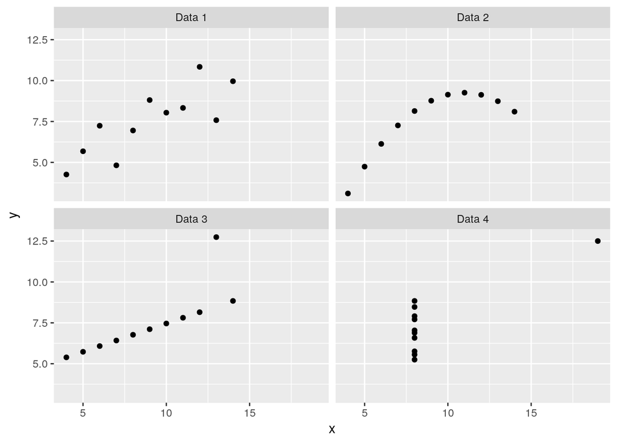

For the example below, we’ll use the x and y values from the first data set in Anscombe’s Quartet.

```r
anscombe1 = data.frame(x = anscombe$x1,
                       y = anscombe$y1)
```

#### Perform a linear regression

Now we perform a linear regression on the data:

```r
z = lm(y~x, data=anscombe1)
```

- `data=anscombe1` means that we want to use the `anscombe1` data frame that we just created
- `y~x` says that we’re trying to predict a response (the value `y`) given the value of a term (`x`). Here `x` and `y` correspond to the actual column names of the data frame. If we were to us a different data frame (like `mtcars`) we would update the formula (for example to predict miles per gallon given horse power, we would use `mpg~hp`).

#### Basic regression output

Using `summary` we can get an overview of the results of the regression

```r
summary(z)
```

```
##
## Call:
## lm(formula = y ~ x, data = anscombe1)
##
## Residuals:
##      Min       1Q   Median       3Q      Max
## -1.92127 -0.45577 -0.04136  0.70941  1.83882
##
## Coefficients:
##             Estimate Std. Error t value Pr(>|t|)
## (Intercept)   3.0001     1.1247   2.667  0.02573 *
## x             0.5001     0.1179   4.241  0.00217 **
## ---
## Signif. codes:  0 '***' 0.001 '**' 0.01 '*' 0.05 '.' 0.1 ' ' 1
##
## Residual standard error: 1.237 on 9 degrees of freedom
## Multiple R-squared:  0.6665, Adjusted R-squared:  0.6295
## F-statistic: 17.99 on 1 and 9 DF,  p-value: 0.00217
```

#### Error bar plots in ggplot

For some data sets, you will also have information available on the error for particular values. Anscombe’s quartet doesn’t contain this information, but for the sake of demonstrating the R syntax to create a plot with error bars, we add a `y_error` column using random values.

```r
anscombe1$y_error = runif(nrow(anscombe1))
```

Now we perform a scatter plot using `geom_point`, but now we also add `geom_errorbar` to add error bars on top of those points. The code `ymin = y - y_error` and `ymax = y + y_error` shows how we use the values from the `y` and `y_error` columns to calculate the top and bottom of the error bars.

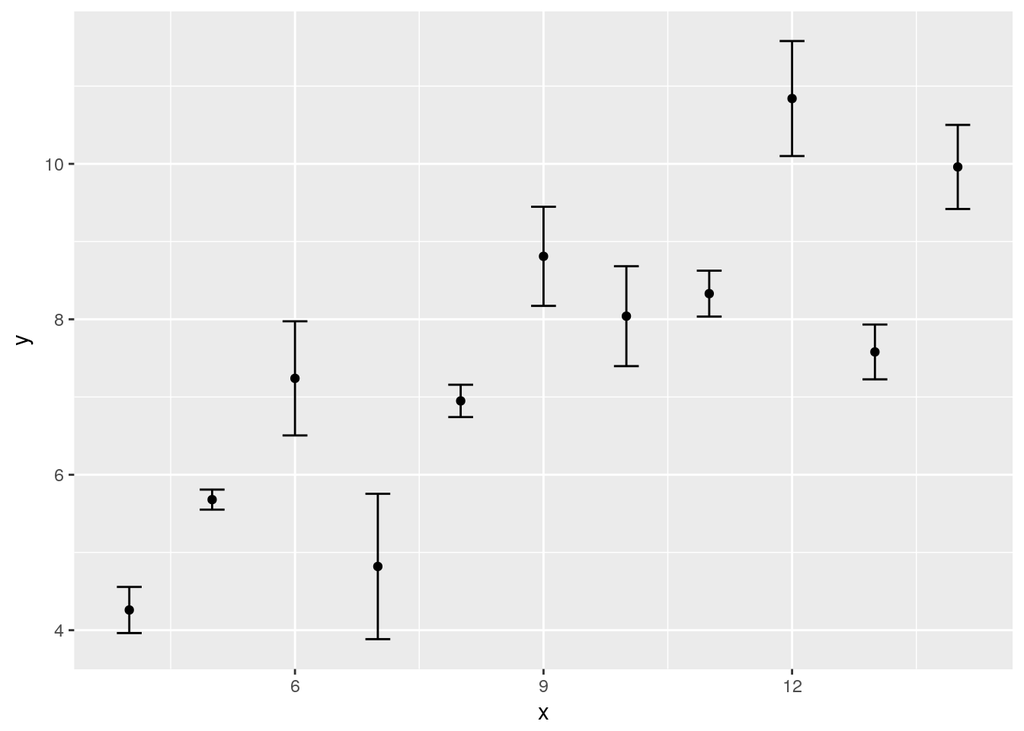

```r
ggplot(anscombe1, aes(x=x, y=y)) + geom_point() +
 geom_errorbar(aes(ymin = y - y_error,
                   ymax = y + y_error,
                   width=0.3)) # width changes the width of the horizontal bar at the top of the error bar
```

In this example, the error bars are “mirrored” around the value of `y`. Since we specify the value of `ymin` independently of `ymax`, then it’s possible that you could use a different formula and/or column so that the observed value of `y` does not lie directly in the middle of the error bars but is skewed to one side.

#### Add a regression line to the error bar plot

We will reuse the same code from above, but will now add in a regression line. To do this, we need to use the coefficients that were found from the linear regression.

```r
z$coefficients
```

```
## (Intercept)           x
##   3.0000909   0.5000909
```

As you can see, the first value is the intercept. The second value is labelled `x` although this refers to the slope of the regression line. We will use these values directly in the `geom_abline` command:

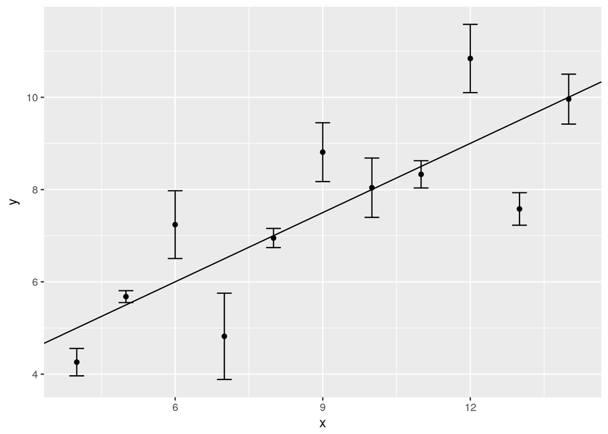

```r
ggplot(anscombe1, aes(x=x, y=y)) + geom_point() +
  geom_errorbar(aes(ymin=y - y_error,
                    ymax=y + y_error,
                    width=0.3)) +
  geom_abline(intercept = z$coefficients[1],
              slope = z$coefficients[2])
```

Alternatively, we can also use `geom_smooth` to perform a linear regression, although for the examples in this practical, we’ll use `geom_abline`. Using `geom_smooth` is a good idea when you have to create a plot with multiple linear regressions that are done on subsets of the data.

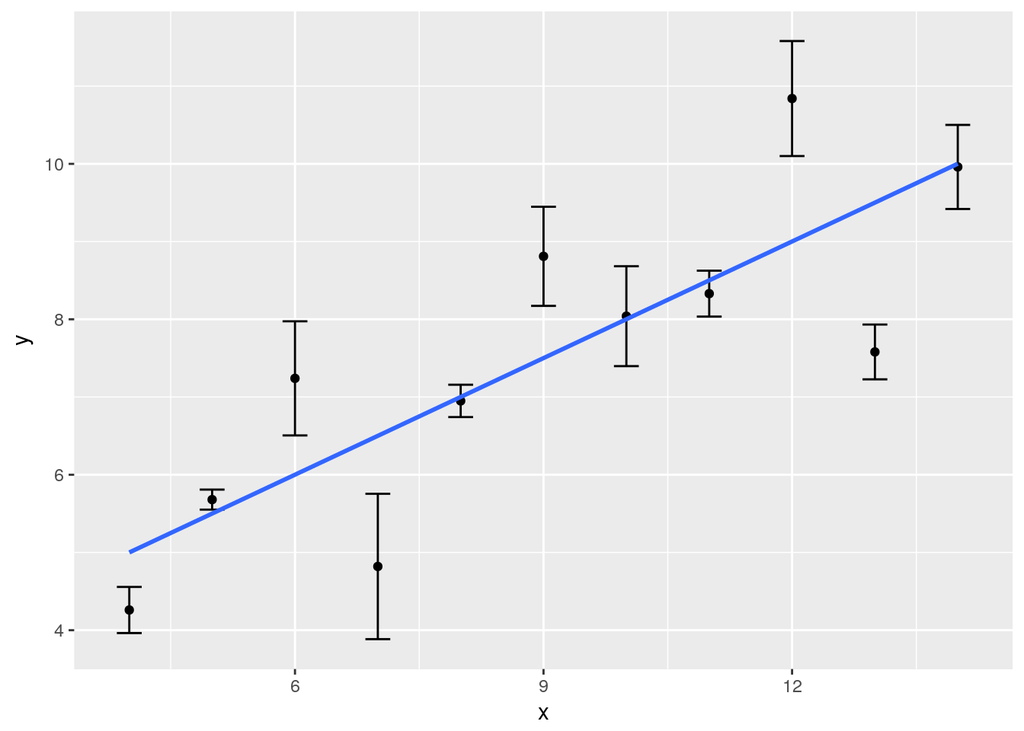

```r
ggplot(anscombe1, aes(x=x, y=y)) + geom_point() +
  geom_errorbar(aes(ymin=y - y_error,
                    ymax=y + y_error,
                    width=0.3)) +
  geom_smooth(aes(x=x, y=y), method="lm", formula=y~x, se=FALSE)
```

One thing which we’ll come back to later is that the linear regressions for the four data sets in Anscombe’s Quartet are nearly identical, even though visually they look quite different:

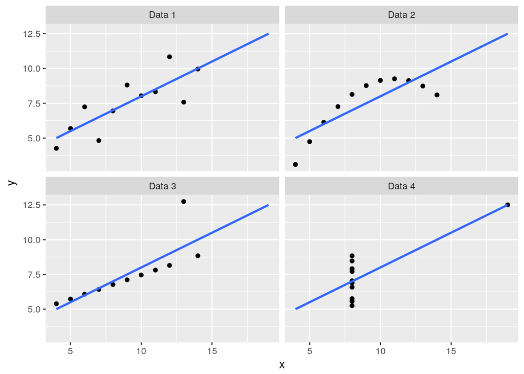

### Exercise

For this exercise, download the data Practical6_Data.txt and load it into R.

#### Make an error bar plot

You should see:

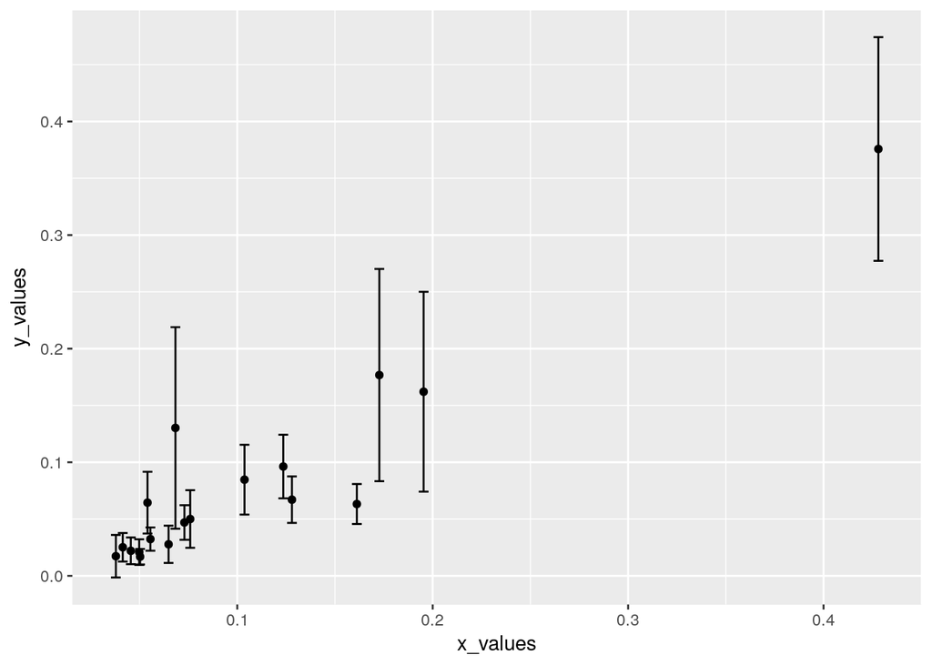

#### Perform a linear regression

Using `summary` on the results, you should see:

```
##
## Call:
## lm(formula = y_values ~ x_values, data = data1)
##
## Residuals:
##       Min        1Q    Median        3Q       Max
## -0.066718 -0.009398 -0.003966  0.004625  0.082318
##
## Coefficients:
##             Estimate Std. Error t value Pr(>|t|)
## (Intercept) -0.01251    0.01131  -1.106    0.285
## x_values     0.88361    0.08043  10.986 7.31e-09 ***
## ---
## Signif. codes:  0 '***' 0.001 '**' 0.01 '*' 0.05 '.' 0.1 ' ' 1
##
## Residual standard error: 0.03105 on 16 degrees of freedom
## Multiple R-squared:  0.8829, Adjusted R-squared:  0.8756
## F-statistic: 120.7 on 1 and 16 DF,  p-value: 7.311e-09
```

#### Add the regression line to the error bar plot

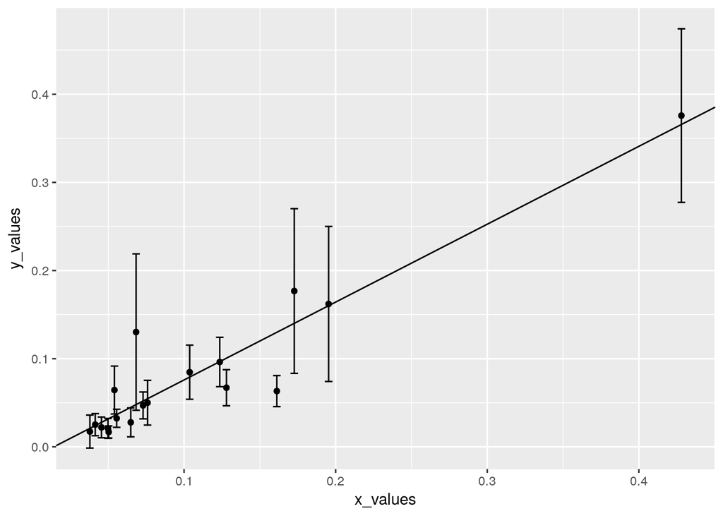

#### Perform a linear regression with weights specified

For the linear regression, we need to specify the weights as `1/(data1$y_errors^2)`

The summary of the linear regression results should show:

```
##
## Call:
## lm(formula = y_values ~ x_values, data = data1, weights = 1/(data1$y_errors^2))
##
## Weighted Residuals:
##     Min      1Q  Median      3Q     Max
## -1.7018 -0.1766  0.5083  0.8713  1.3991
##
## Coefficients:
##              Estimate Std. Error t value Pr(>|t|)
## (Intercept) -0.007306   0.006987  -1.046    0.311
## x_values     0.623074   0.099661   6.252 1.16e-05 ***
## ---
## Signif. codes:  0 '***' 0.001 '**' 0.01 '*' 0.05 '.' 0.1 ' ' 1
##
## Residual standard error: 0.8809 on 16 degrees of freedom
## Multiple R-squared:  0.7095, Adjusted R-squared:  0.6914
## F-statistic: 39.09 on 1 and 16 DF,  p-value: 1.156e-05
```

#### Plot both linear regressions (with and without weights)

Remember that with ggplot, you can append commands like `+ geom_abline(..., color="blue") + geom_abline(..., color="red")`

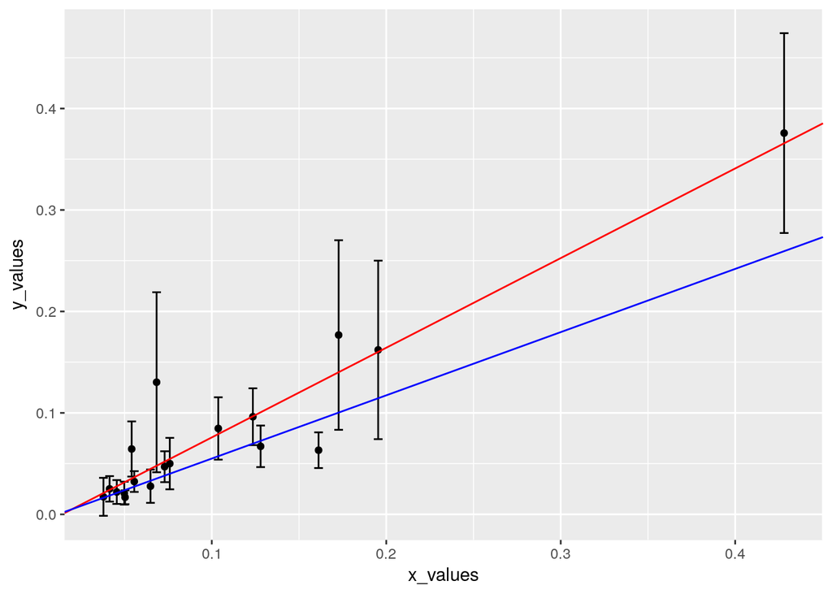

## Regression diagnostic

### Residuals ($\epsilon_i$)

#### Reminder from the lecture

- $E(\epsilon_i|X_i) = 0$ (residuals should have mean 0 for all $X_i$ )
- $\epsilon_i$ is normally distributed (residuals are normally distributed with mean = 0 and variance $Var(\epsilon_i) = s_2$, for all $\epsilon_i$

#### Syntax

For plotting residuals against fitted values, we’ll again use the `anscombe1` data frame that we created above, using the same code for the linear regression:

```r
z = lm(y~x, anscombe1)
```

Now we get the fitted values corresponding to each value of x:

```r
fit <- fitted(z)
print(fit)
```

```
##         1         2         3         4         5         6         7
##  8.001000  7.000818  9.501273  7.500909  8.501091 10.001364  6.000636
##         8         9        10        11
##  5.000455  9.001182  6.500727  5.500545
```

We then get the residuals:

```r
res <- residuals(z)
print(res)
```

```
##           1           2           3           4           5           6
##  0.03900000 -0.05081818 -1.92127273  1.30909091 -0.17109091 -0.04136364
##           7           8           9          10          11
##  1.23936364 -0.74045455  1.83881818 -1.68072727  0.17945455
```

Add in columns to the `anscombe1` data frame for the fit and res values

```r
anscombe1$fit = fit
anscombe1$res = res
```

We can see that the fitted values follow the regression line:

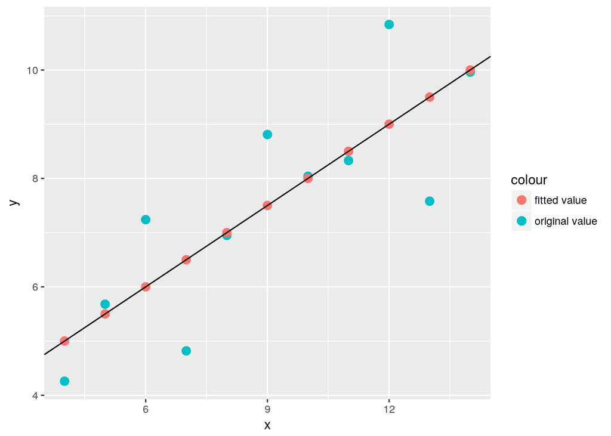

```r
ggplot(anscombe1) +
  geom_point(aes(x=x, y=y, color="original value"), size=3) +
  geom_point(aes(x=x, y=fit, color="fitted value"), size=3) +
  geom_abline(intercept = z$coefficients[1], slope=z$coefficients[2])
```

In the code above, we have the statements `color="original value"` and `color="fitted value"`. When ggplot sees statements like these withing `aes(...)` it will automatically assign a color to each of these text values. What is happening is the same as what you would get when using something like `aes(..., color=some_column_name)`. In this case, every distinct value of `some_column_name` will be assigned a unique color.

Show the residuals that were calculated:

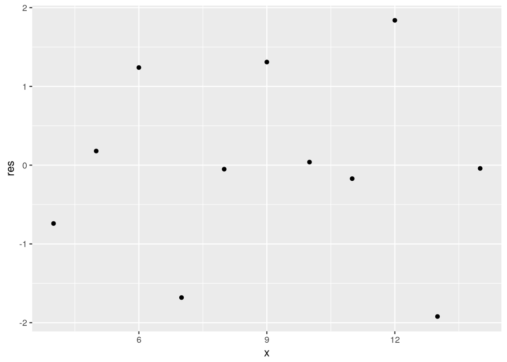

```r
ggplot(anscombe1) +
  geom_point(aes(x=x, y=res))
```

Putting this all together we can see how subtracting the residual from the original `y` values gives us the fitted values in `fit`. Note that `geom_segment` allows us to draw line segments from the points defined at `x`,`y` to the point at `xend`,`yend`

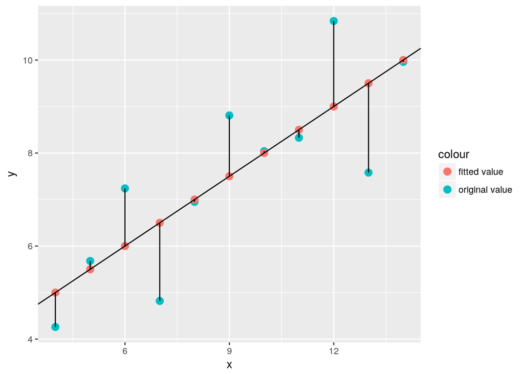

```r
ggplot(anscombe1) +
  geom_point(aes(x=x, y=y, color="original value"), size=3) +
  geom_point(aes(x=x, y=fit, color="fitted value"), size=3) +
  geom_segment(aes(x=x, xend=x, y=y, yend=y-res)) +
  geom_abline(intercept = z$coefficients[1], slope=z$coefficients[2])
```

Plot residual against fitted values:

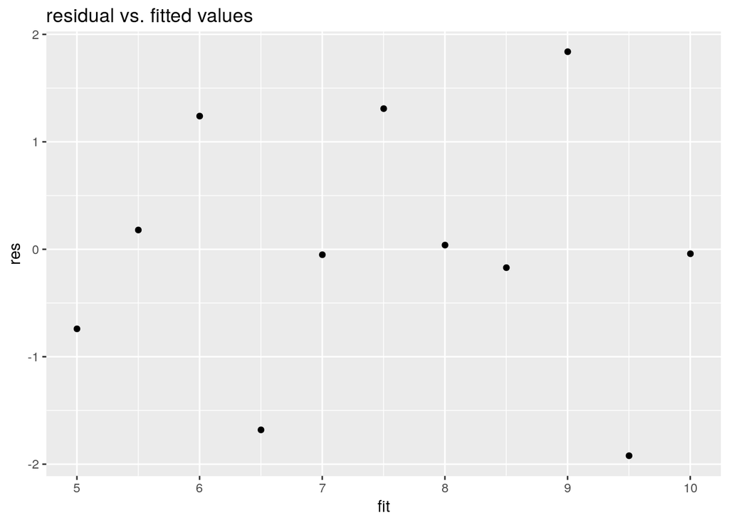

```r
ggplot(anscombe1, aes(x=fit, y=res)) + geom_point() + ggtitle("residual vs. fitted values")
```

Perform a qqnorm plot of residuals to see if they are normally distributed:

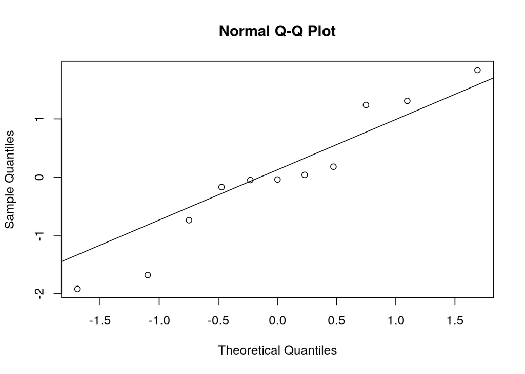

```r
qqnorm(res)
qqline(res)
```

#### Exercise

Make the plots of fitted values vs residuals for the data from `Practical6_Data.txt`

Perform a linear regression without weights:

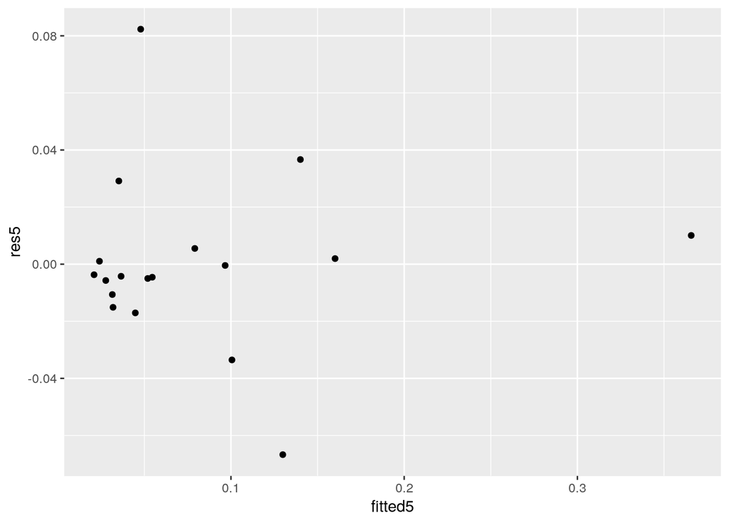

Make a qnorm plot of the residuals:

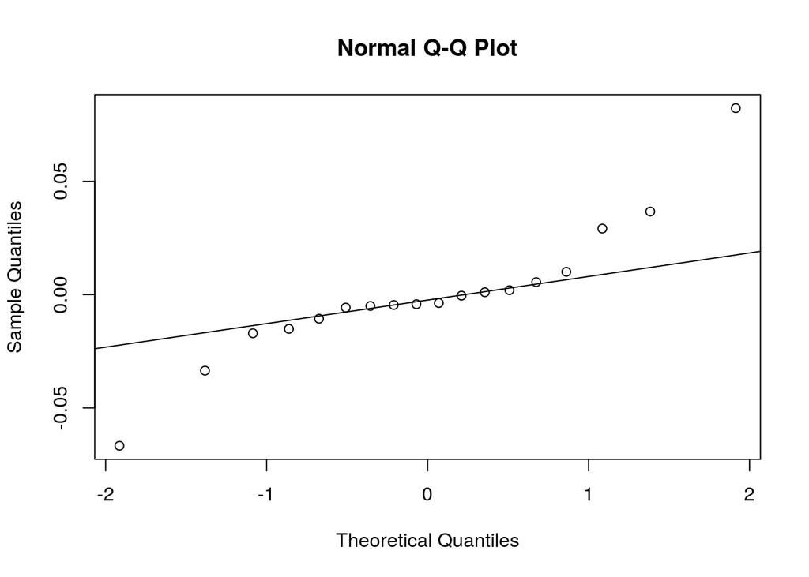

Linear regression with weights (performed same as earlier in the practical):

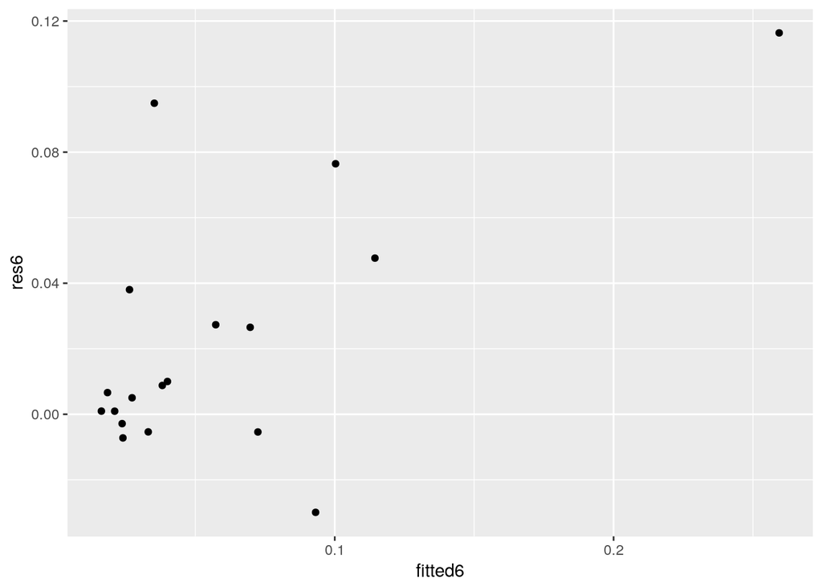

Make a qnorm plot of the residuals (using the weighted model):

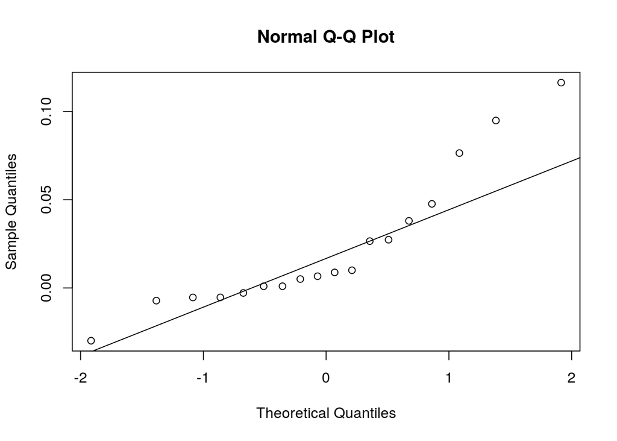

### Cook’s distance

#### Reminder of the lecture

The cook’s distance of point $X_i$ is a measure of the difference in regression parameters when the point is included or omitted. If omitting a point changes the regression parameters strongly, this point has a large Cook’s distance.

To see quantitatively if the Cook’s distance of a data point is too large and it has an undue influence on the fit you need to compare it with a theoretical cut-off. This cutoff value can be calculated with the F-statistic using `qf(0.5, p, n-p, lower.tail = FALSE)` where:

- `p` - fitted parameters (=2 with simple linear regression)
- `n` - number of data points

#### Syntax

Below we use the `anscombe1` data frame again.

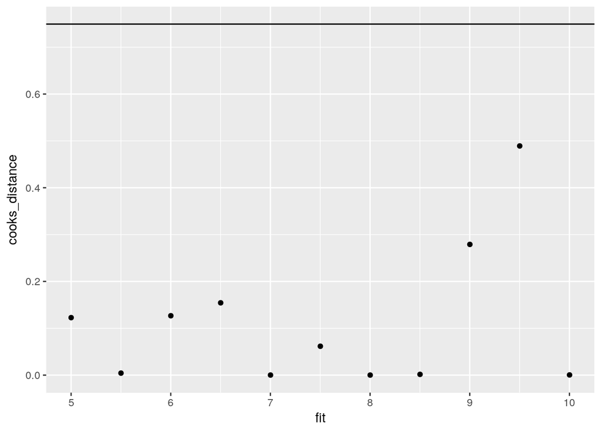

```r
##Cook's distance

z = lm(y~x, data=anscombe1)
cook <- cooks.distance(z)

## put the fitted values and Cook's distance into a data frame
data = data.frame(fit = fitted(z),
                  cooks_distance = cook)

##cut-off value
cut <- qf(0.5, 2, length(data$fit)-2, lower.tail = FALSE)

ggplot(data, aes(x=fit, y=cooks_distance)) + geom_point() + geom_hline(yintercept=cut)
```

If we look at all four data sets in Anscombe’s Quartet, there are quite different outcomes when plotting the Cook’s distance for each.

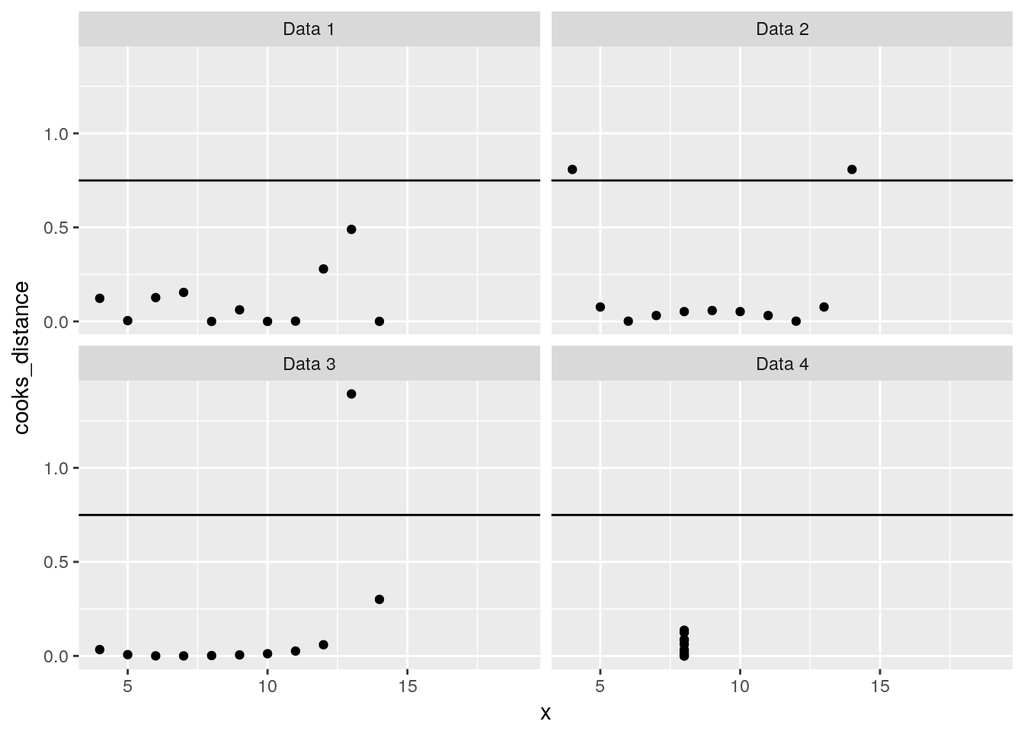

#### Exercise

For the unweighted and weighted fit, compare the cooks distance

Unweighted fit:

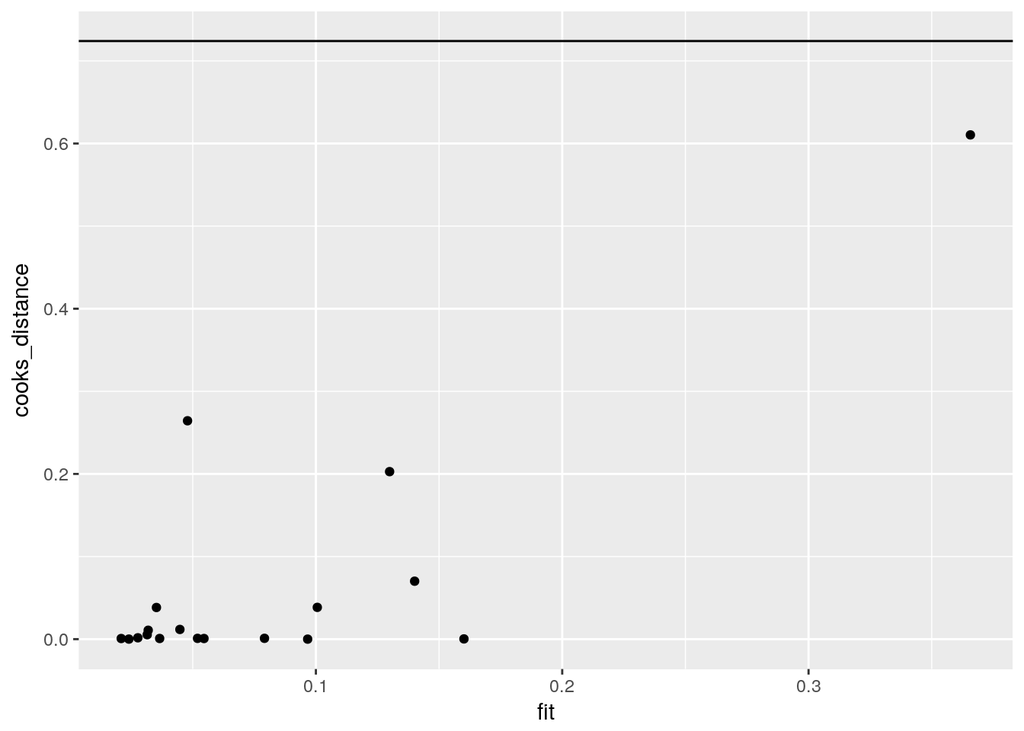

Weighted fit:

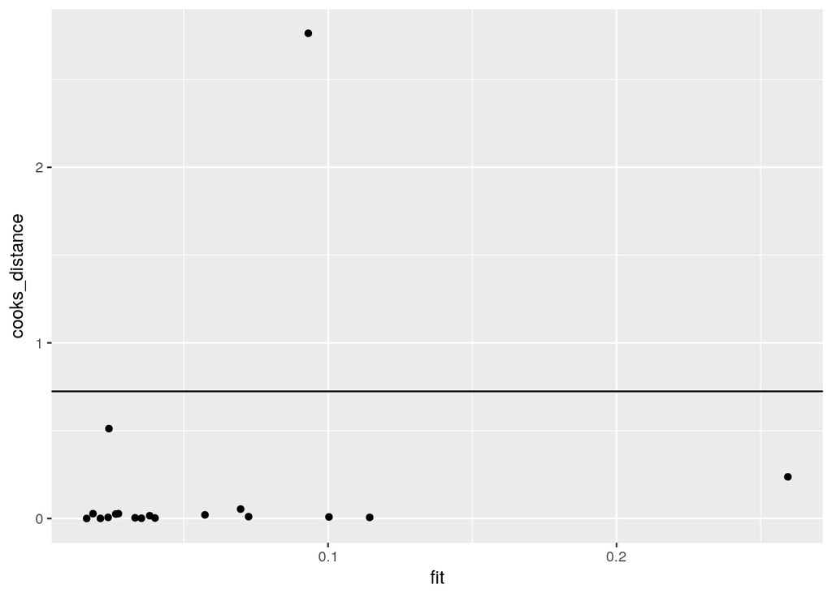

### Automatic diagnostic plots

We can create a series of diagnostic plots for the linear regression results by simply using `plot(z)` (where `z` is the output of a linear regression) instead of `ggplot`. What’s happening here is that R detects that `z` is the result of a linear regression, and whenever it sees this, it will create a series of four plots:

- Residuals vs. Fitted
- Normal Q-Q
- Scale-Location (not covered in this practical)
- Residuals vs. Leverage (related to Cook’s distance)

Here we create the diagnostic plots for the linear regression of the `anscombe1` data frame:

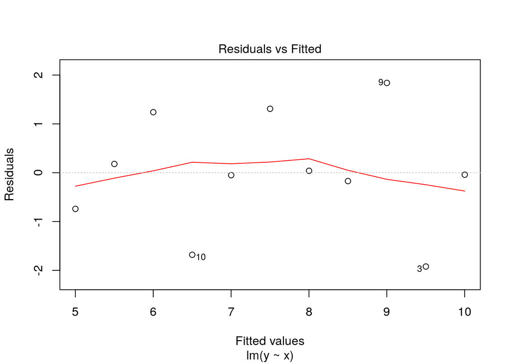

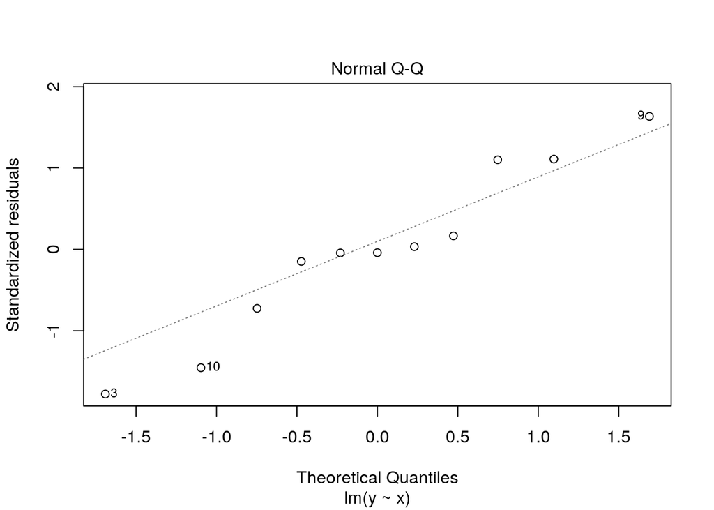

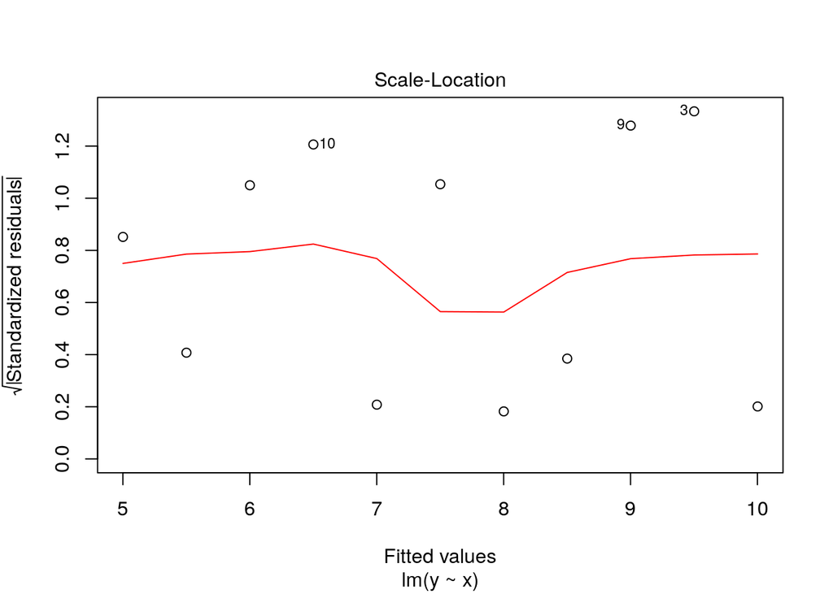

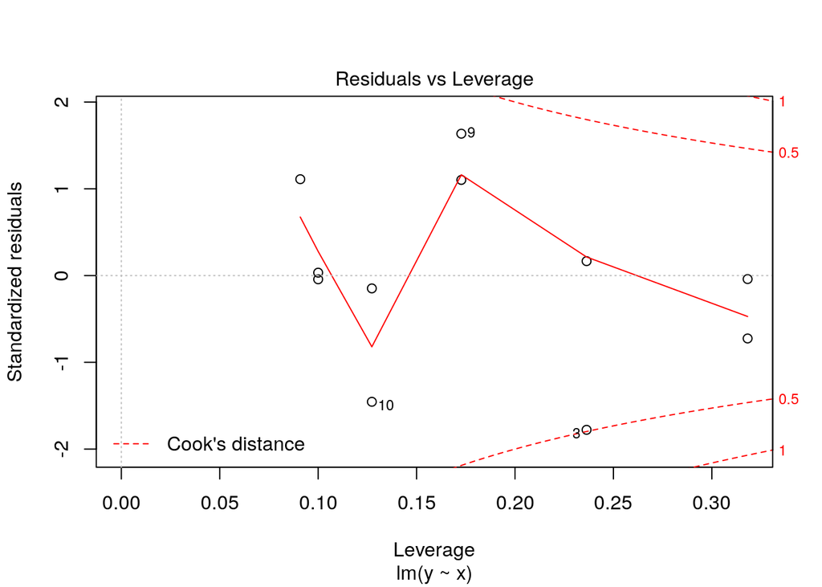

```r
z = lm(y~x, data=anscombe1)
plot(z)
```

#### Exercise

Create diagnostic plots for both the unweighted and weighted regressions that you just did.

##### Diagnostic plots for unweighted fit

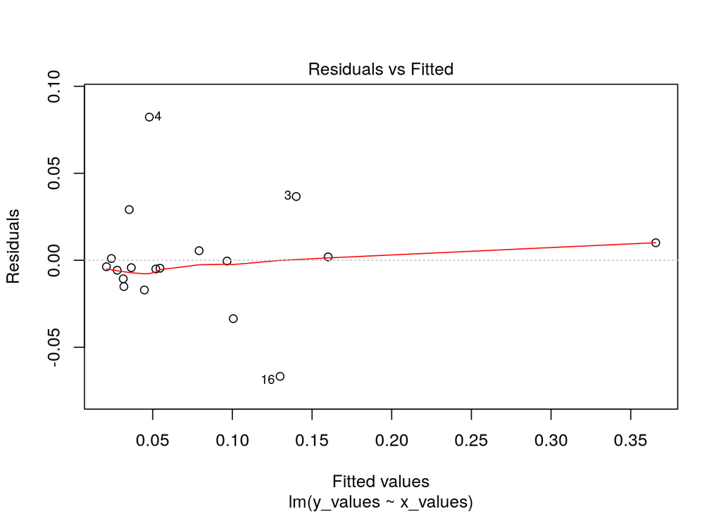

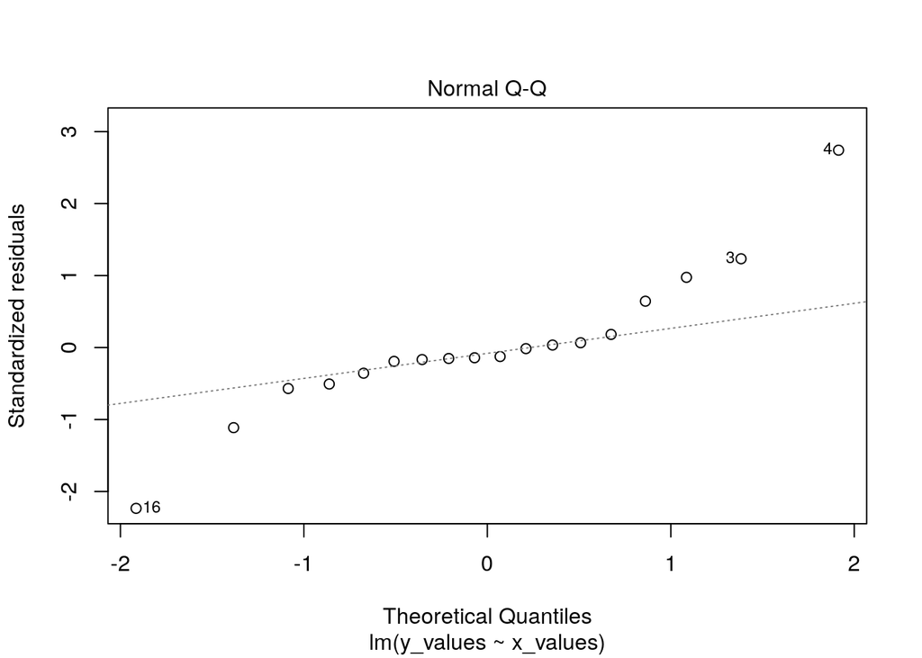

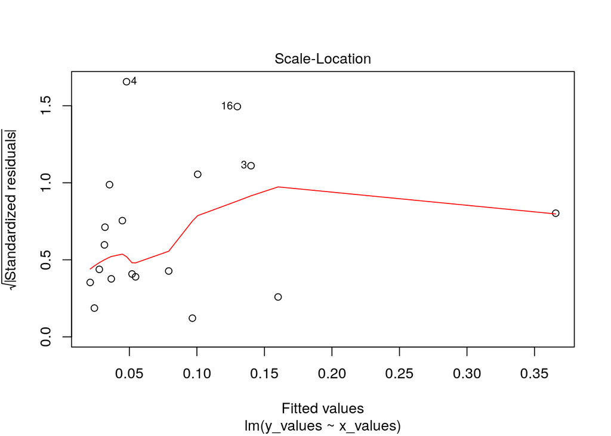

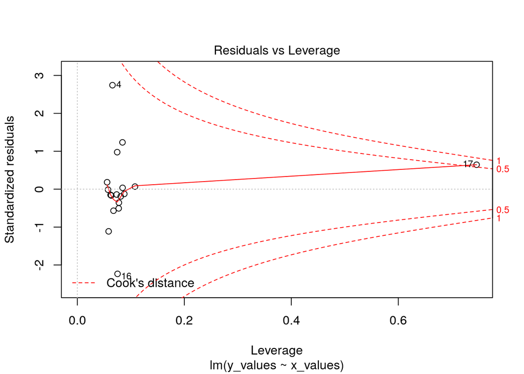